# Praca domowa 3

Czy warto stosować wykres kołowy 3D?

Aliaksei Shaukunou

2023-03-26

### Cele

Głownym celem danej pracy jest sprawdzanie, czy faktycznie warto ostrożnie wybierać kolory przy wizualizacji danych, używać wykresy 3D i wykresy kołowe.

### Opis eksperymentu

Żeby osiągnąć nasz cel, stworzyliśmy dwa wykresy na podstawie danych od WHO. Dane te reprezentują procent osób w wieku 15-19 lat, które spożywają alkoholu, w roku 2016:

| Country | 15-19 years old, current drinkers (%) |
| --- | --- |
| Czechia | 64.6 |
| Germany | 70.2 |
| Latvia | 65.3 |
| Lithuania | 70.6 |
| Poland | 55.6 |
| Slovakia | 56.5 |

##### “Zły” wykres

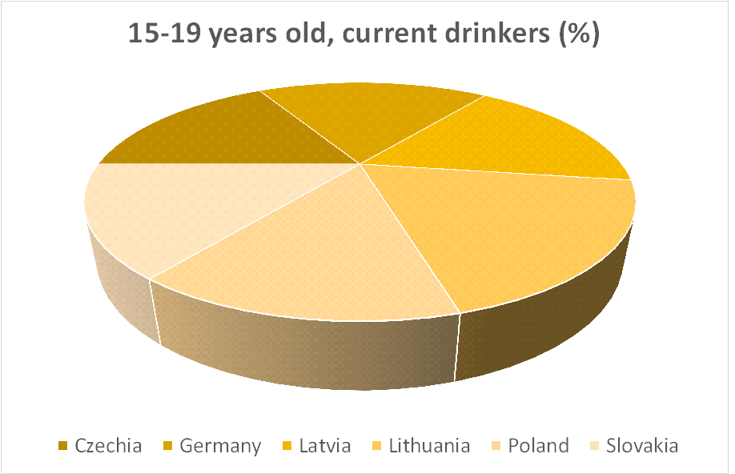

15-19 years old, current drinkers (%)

##### “Dobry” wykres

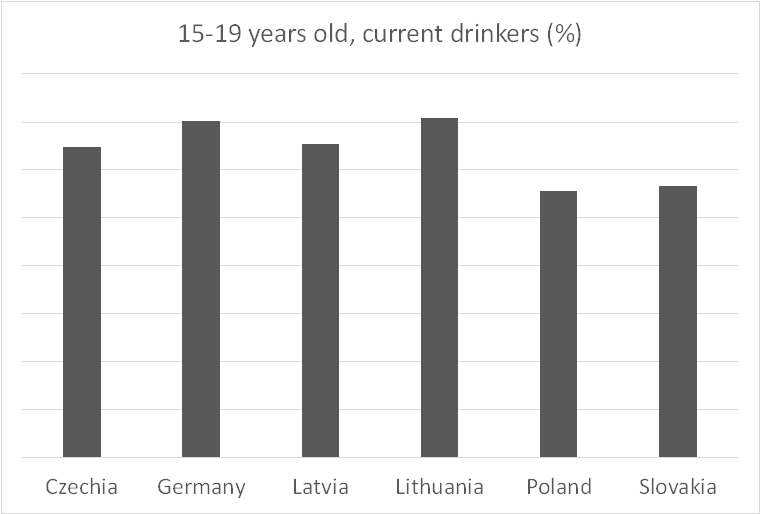

15-19 years old, current drinkers (%)

Przeprowadzono ankietę, składająca się z następujących pytań (wszystkie pytania, oprócz ostatniego, dotyczyły wykresu kołowego):

1. Basing on this chart, do you think that the percentage of drinkers is almost equal in named countries?
2. Basing on this chart, which country in your opinion has the highest percentage of drinkers?
3. Basing on this chart, do you think the percentage of drinkers is higher in Poland or Germany?
4. Was it comfortable to read this chart?
5. What makes the reading of this chart complicated?
6. In your opinion, is this chart better than the one above?

[Link do ankiety](https://docs.google.com/forms/d/e/1FAIpQLSd8eFwN0IAgeuZBb02g0kqH-HmSHgso42k5c-8Z8Map8Jypgw/viewform?usp=sf_link)

### Wyniki ekperymentu

W ankiecie wzięło udział 35 osób. Poniżej się znajdują wykresy, przedstawiające wyniki ankiety.

1. Basing on this chart, do you think that the percentage of drinkers is almost equal in named countries?

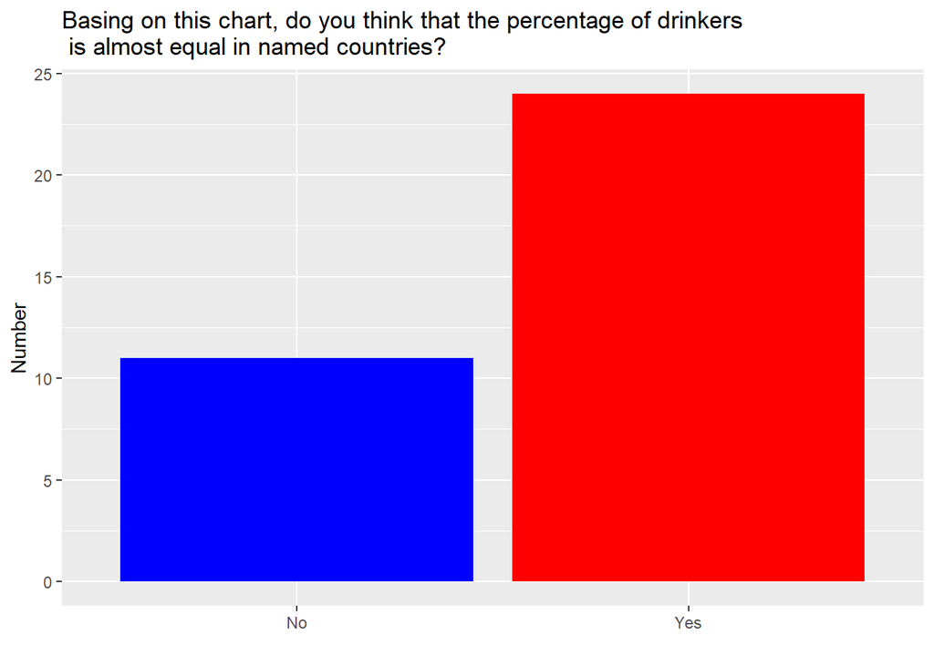

```r
answers %>% ggplot(aes(x = Basing.on.this.chart..do.you.think.that.the.percentage.of.drinkers.is.almost.equal.in.named.countries. )) + geom_bar(fill=c("blue", "red")) + labs(title='Basing on this chart, do you think that the percentage of drinkers\n is almost equal in named countries?', x = '', y = 'Number')
```

2. Basing on this chart, which country in your opinion has the highest percentage of drinkers?

Pytanie wielokrotnego wyboru

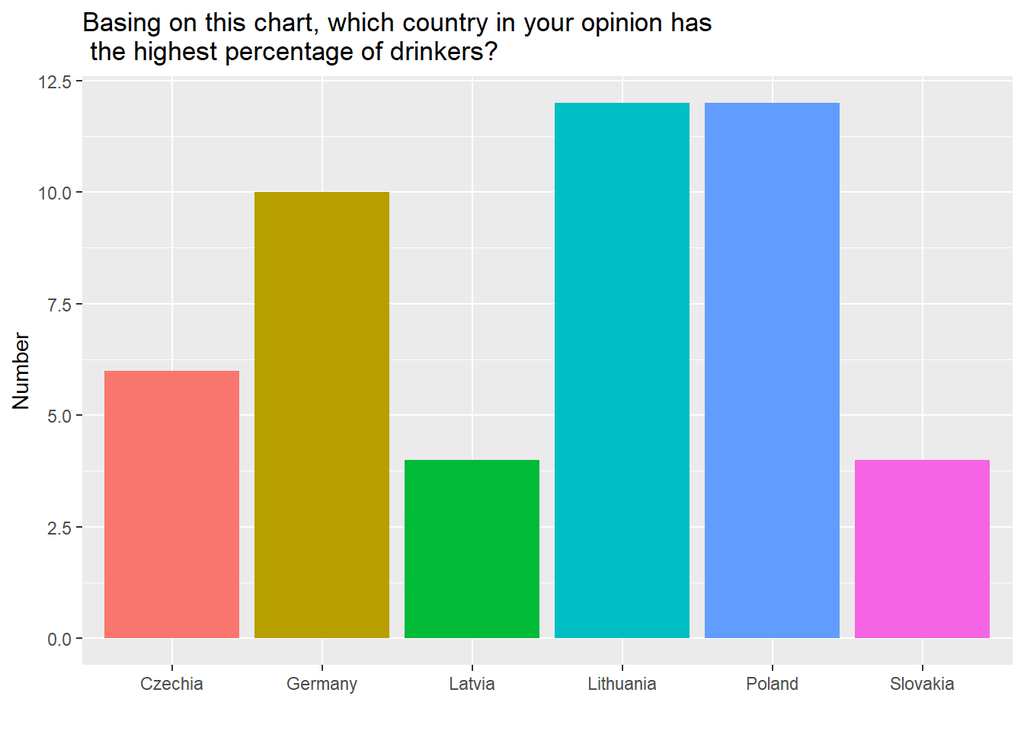

```r
answers$Basing.on.this.chart..which.country.in.your.opinion.has.the.highest.percentage.of.drinkers. %>%
  str_split(';') %>% unlist() %>% data.frame() -> results2
results2 %>% ggplot(aes(x = . , fill = .)) + geom_bar() + labs(title='Basing on this chart, which country in your opinion has\n the highest percentage of drinkers?', x = '', y = 'Number') + theme(legend.position="none")
```

3. Basing on this chart, do you think the percentage of drinkers is higher in Poland or Germany?

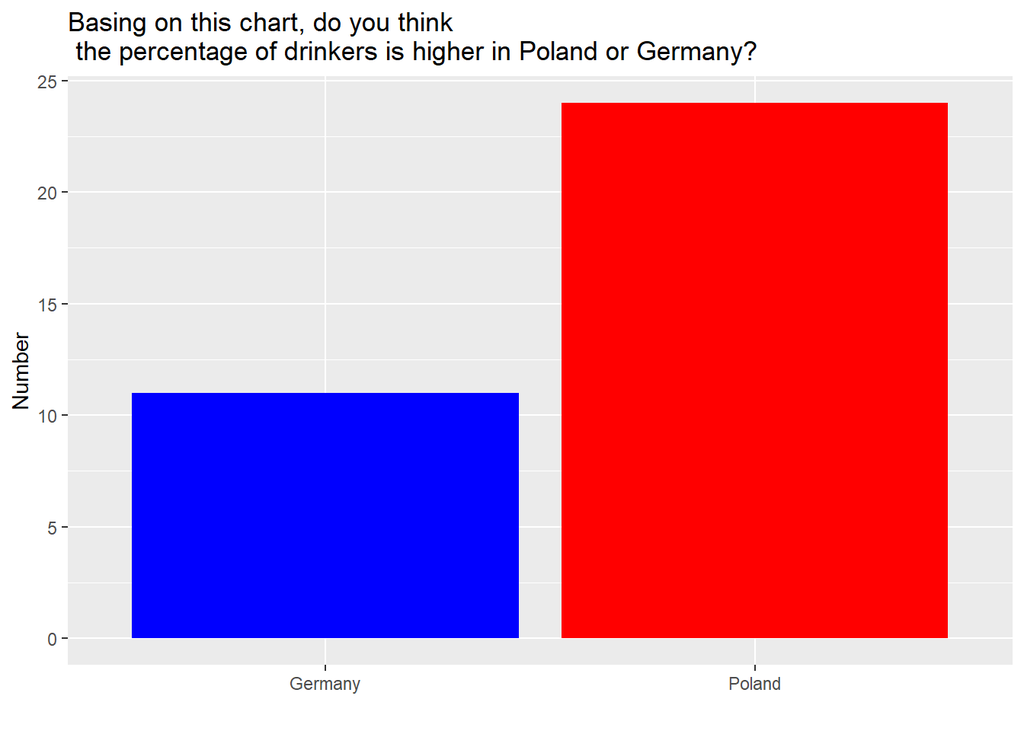

```r
answers %>% ggplot(aes(x = Basing.on.this.chart..do.you.think.the.percentage.of.drinkers.is.higher.in.Poland.or.Germany.)) + geom_bar(fill=c("blue", "red")) + labs(title='Basing on this chart, do you think\n the percentage of drinkers is higher in Poland or Germany?', x = '', y = 'Number')
```

4. Was it comfortable to read this chart?

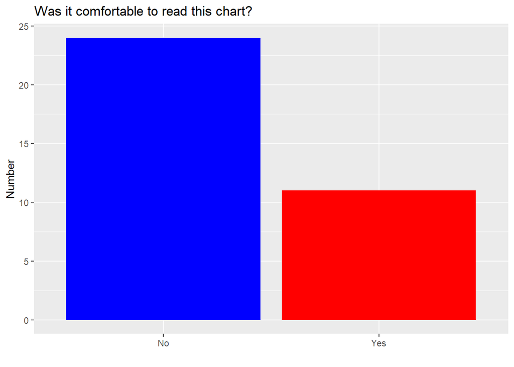

```r
answers %>% ggplot(aes(x = Was.it.comfortable.to.read.this.chart.)) + geom_bar(fill=c("blue", "red")) + labs(title='Was it comfortable to read this chart?', x = '', y = 'Number')
```

5. What makes the reading of this chart complicated?

Pytanie wielokrotnego wyboru

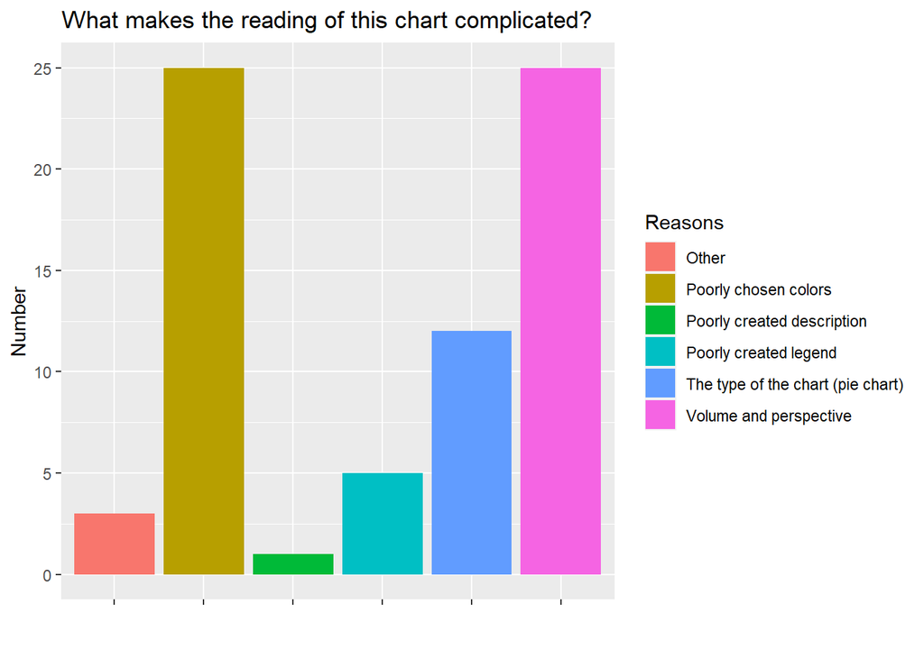

```r
answers$What.makes.the.reading.of.this.chart.complicated. %>%
  str_split(';') %>% unlist()  -> results
case_when(
  results %in% c('Poorly chosen colors', 'The type of the chart (pie chart)',
                 'Volume and perspective', 'Poorly created legend',
                 'Poorly created description') ~ results,
  TRUE ~ 'Other') %>% data.frame() -> results
results %>% ggplot(aes(x = . , fill = .)) + geom_bar() + labs(title='What makes the reading of this chart complicated?', x = '', y = 'Number', fill = 'Reasons') + scale_x_discrete(labels=rep('', 10))
```

6. In your opinion, is this chart better than the one above?

Tu był pokazany wykres słupkowy

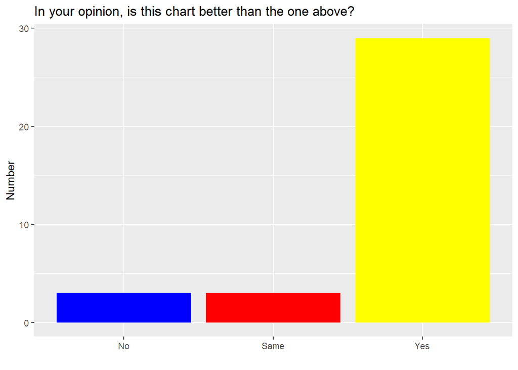

```r
answers %>% ggplot(aes(x = In.your.opinion..is.this.chart.better.than.the.one.above.)) + geom_bar(fill=c("blue", "red", "yellow")) + labs(title='In your opinion, is this chart better than the one above?', x = '', y = 'Number')
```

### Podsumowanie

Jak widać, w większości przypadków ludzie źle odpowiadali na pytania dotyczące porównań, ale byli świadomi, co mogło prowadzić ich w bład. Stąd można (przynajmniej) wywnioskować, że: 1. zły dobór kolorow bardzo utrudnia czytanie wykresu; 2. objętość wykresu może prowadzić osobę, która czyta wykres, w błąd.